# The effect of tarrif reduction on consumer price

Dor Meir

August 22, 2019

# Data exploration - graphs of nominal price

```
## # A tibble: 2,242 x 7
##    brand_name     price_nom date_n month  year  tuna sardin
##    <fct>              <dbl>  <dbl> <fct> <dbl> <dbl>  <dbl>
##  1 starkist_m_big      37.9  12014 dec    2014     1      0
##  2 starkist_m_big      39.5  22015 jan    2015     1      0
##  3 starkist_m_big      38.0  32015 feb    2015     1      0
##  4 starkist_m_big      35.9  42015 mar    2015     1      0
##  5 starkist_m_big      38.2  52015 apr    2015     1      0
##  6 starkist_m_big      36.1  62015 may    2015     1      0
##  7 starkist_m_big      36.6  72015 jun    2015     1      0
##  8 starkist_m_big      39.3  82015 jul    2015     1      0
##  9 starkist_m_big      37.8  92015 aug    2015     1      0
## 10 starkist_m_big      38.1 102015 sep    2015     1      0
## # ... with 2,232 more rows
```

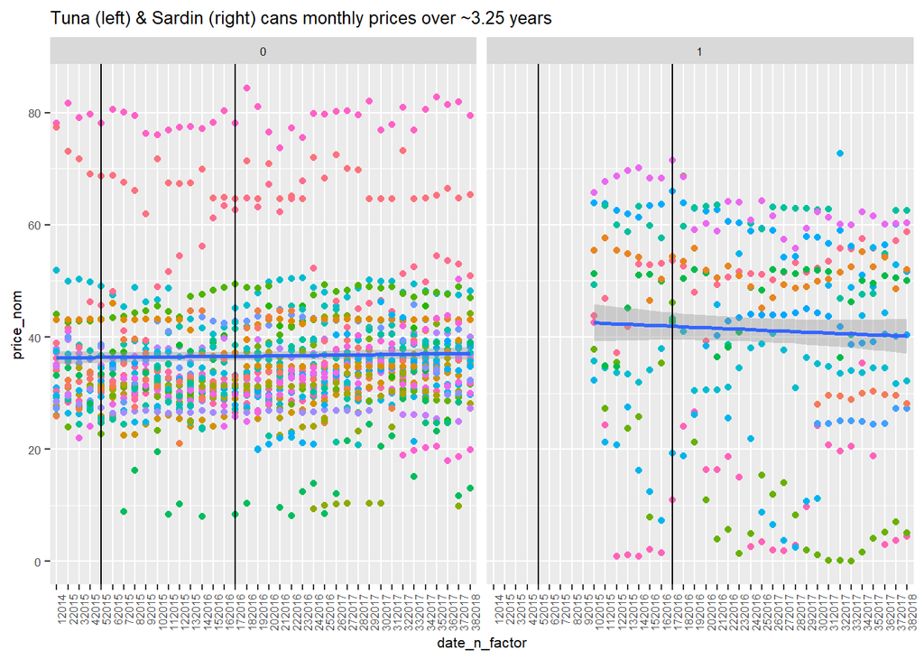

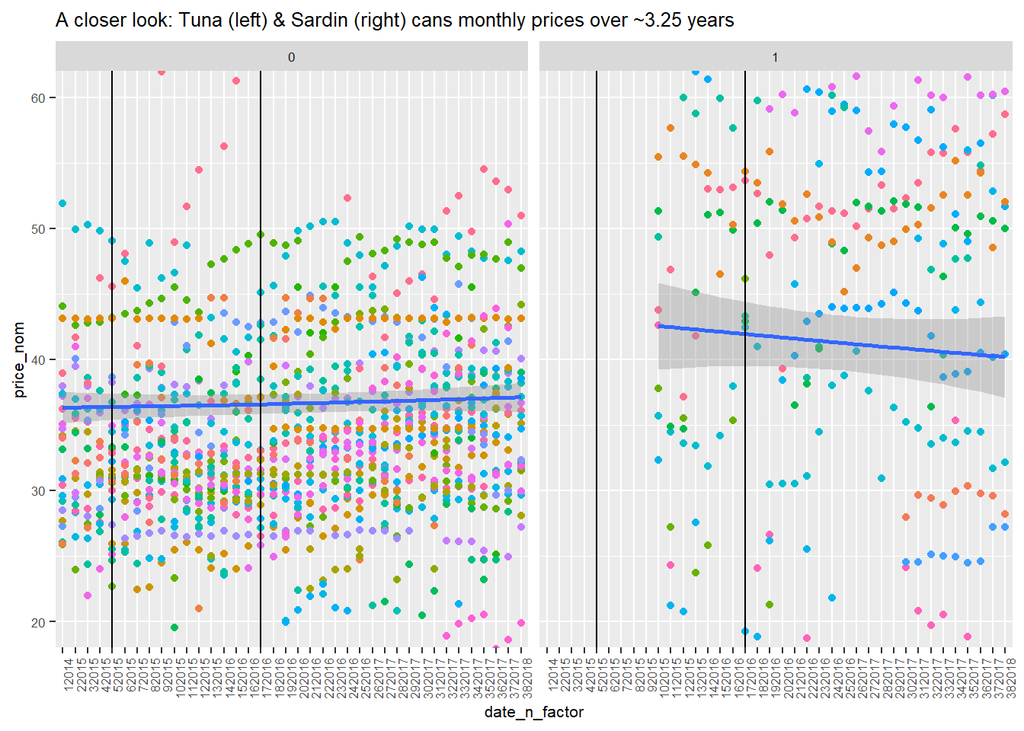

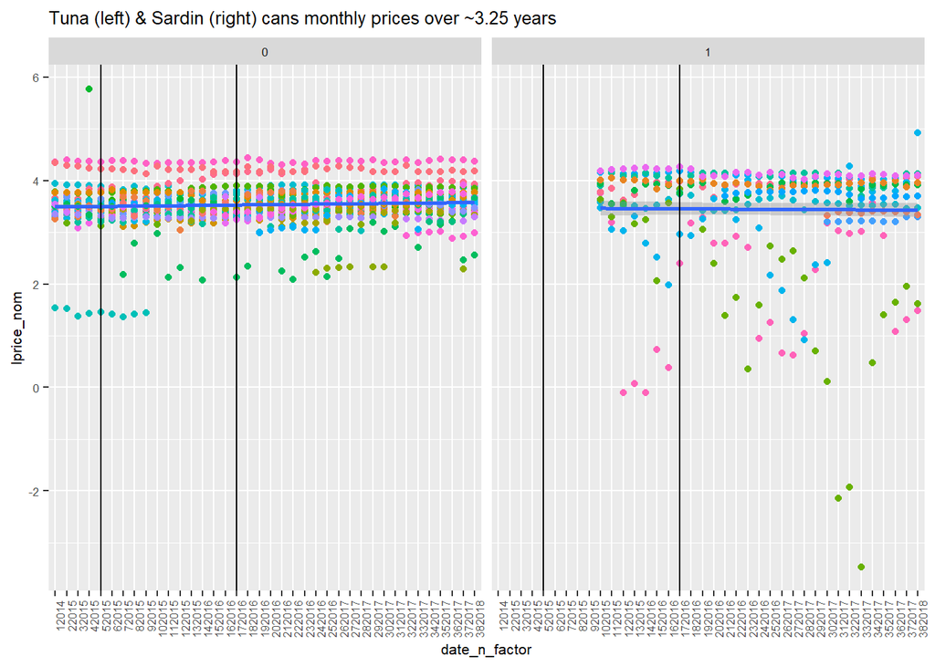

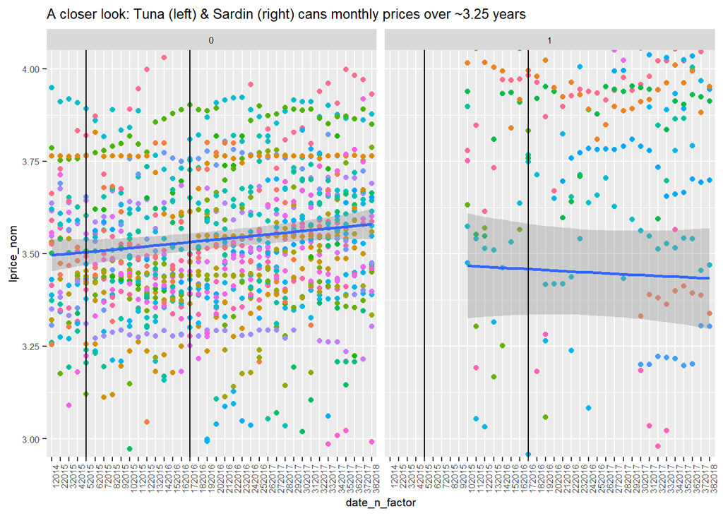

```
## # A tibble: 1,363 x 7
##    brand_name    price_nom date_n month  year olive cooking_oil
##    <fct>             <dbl>  <dbl> <fct> <dbl> <dbl>       <dbl>
##  1 yad_mordechai      36.9 102015 sep    2015     1           0
##  2 yad_mordechai      43.3 112015 oct    2015     1           0
##  3 yad_mordechai      45.2 122015 nov    2015     1           0
##  4 yad_mordechai      45.5 132015 dec    2015     1           0
##  5 yad_mordechai      37.6 142016 jan    2016     1           0
##  6 yad_mordechai      40.6 152016 feb    2016     1           0
##  7 yad_mordechai      42.5 162016 mar    2016     1           0
##  8 yad_mordechai      39.3 172016 apr    2016     1           0
##  9 yad_mordechai      41.8 182016 may    2016     1           0
## 10 yad_mordechai      39.0 192016 jun    2016     1           0
## # ... with 1,353 more rows
```

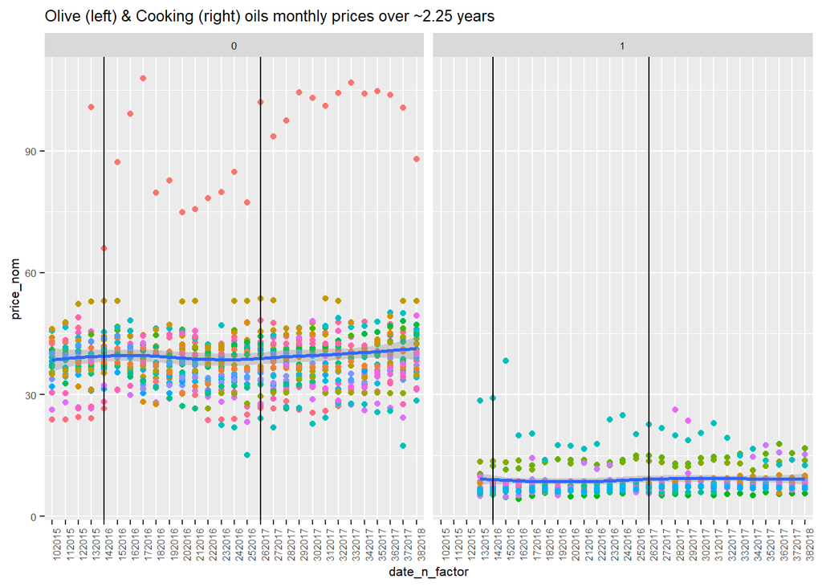

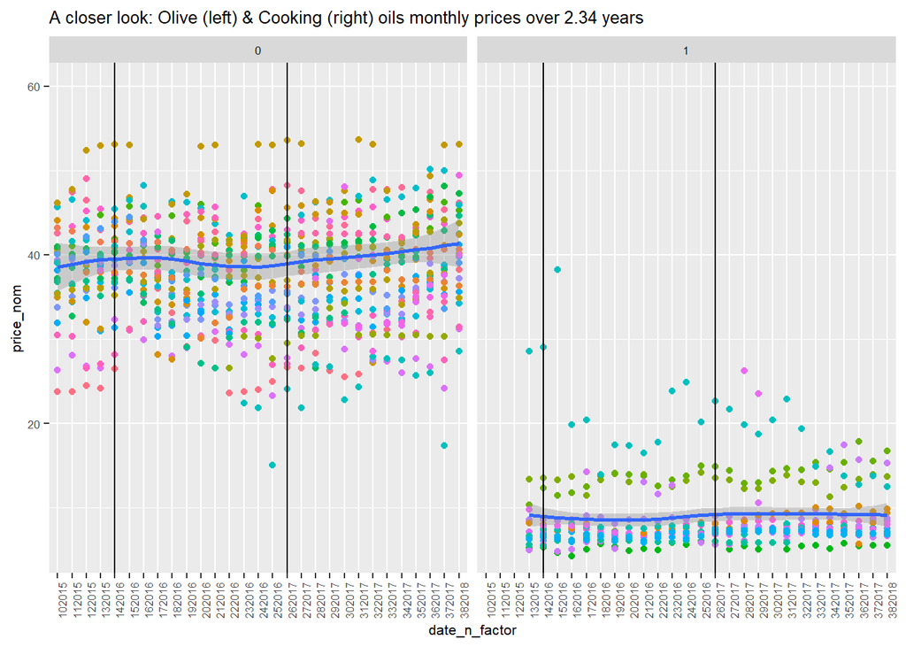

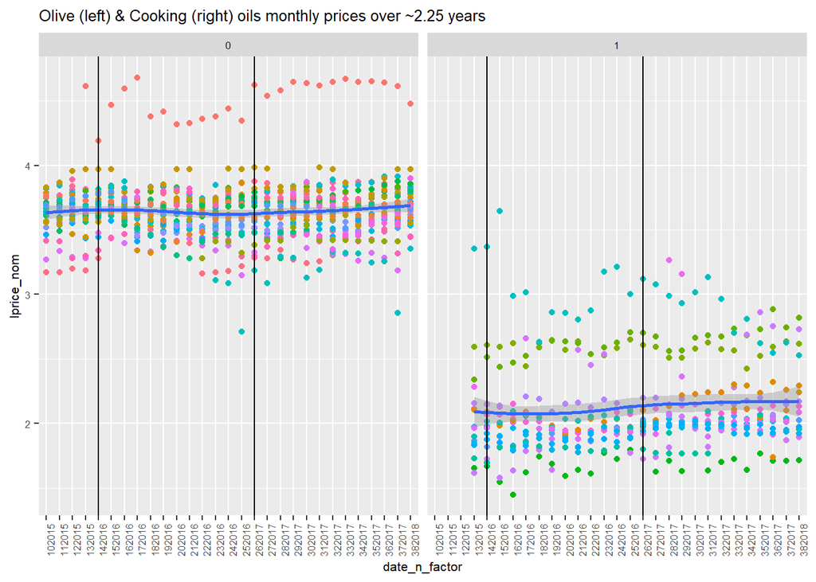

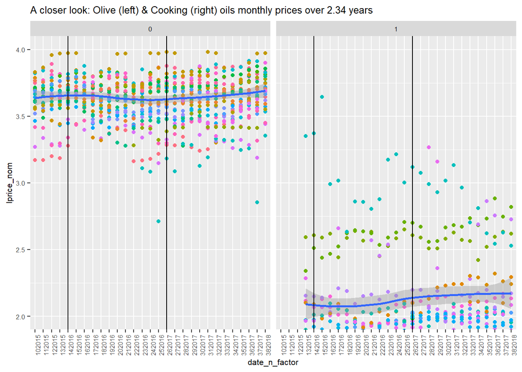

```
## # A tibble: 1,189 x 7
##    brand_name price_nom date_n month  year yellow white_cheese
##    <fct>          <dbl>  <dbl> <fct> <dbl>  <dbl>        <dbl>
##  1 emek            55.7 102015 sep    2015      1            0
##  2 emek            55.8 112015 oct    2015      1            0
##  3 emek            55.4 122015 nov    2015      1            0
##  4 emek            55.2 132015 dec    2015      1            0
##  5 emek            54.9 142016 jan    2016      1            0
##  6 emek            55.1 152016 feb    2016      1            0
##  7 emek            54.7 162016 mar    2016      1            0
##  8 emek            55.5 172016 apr    2016      1            0
##  9 emek            55.4 182016 may    2016      1            0
## 10 emek            53.7 192016 jun    2016      1            0
## # ... with 1,179 more rows
```

[figure not shown]

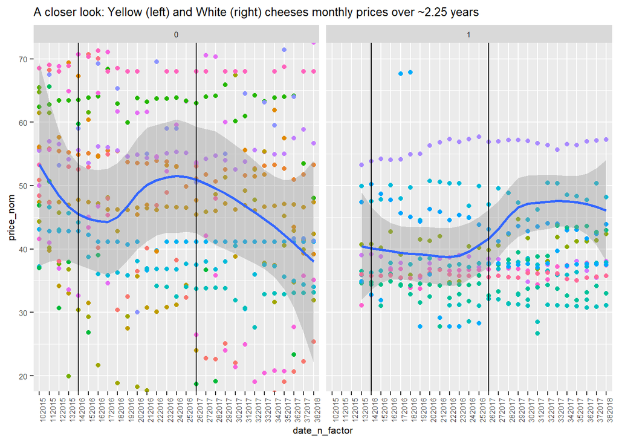

[figure not shown]

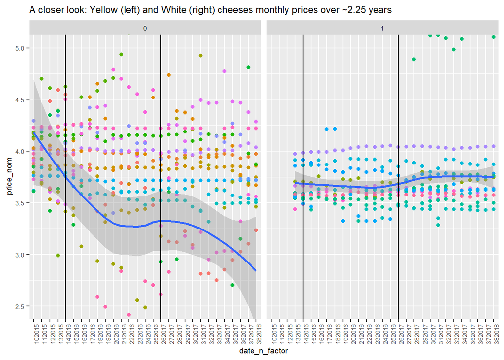

# Tree models

“At every node, a set of possible split points is identified for every predictor variable. The algorithm calculates the improvement in purity of the data that would be created by each split point of each variable. The split with the greatest improvement is chosen to partition the data and create child nodes.”

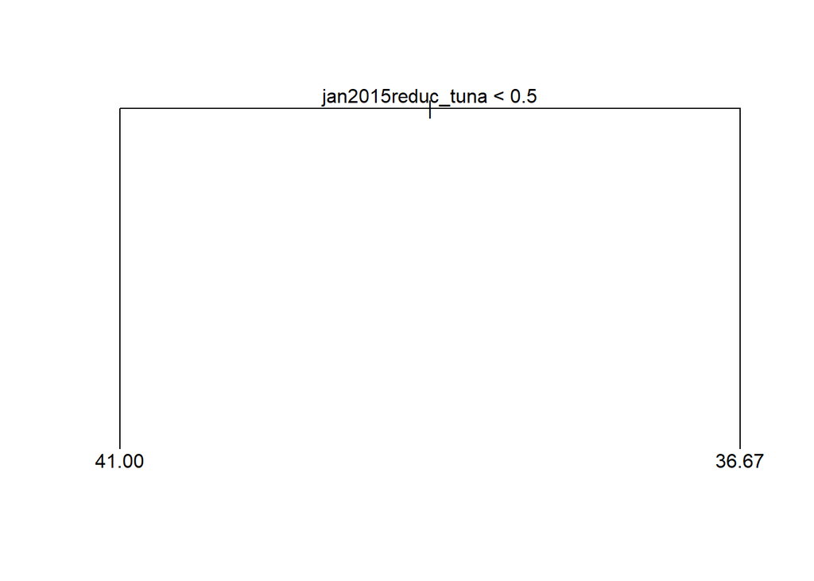

```r
tuna_tree <- tree( price_nom ~ jan2015reduc + jan2015reduc_tuna + jan2016reduc + jan2016reduc_tuna , tuna)
plot(tuna_tree)
text(tuna_tree)
```

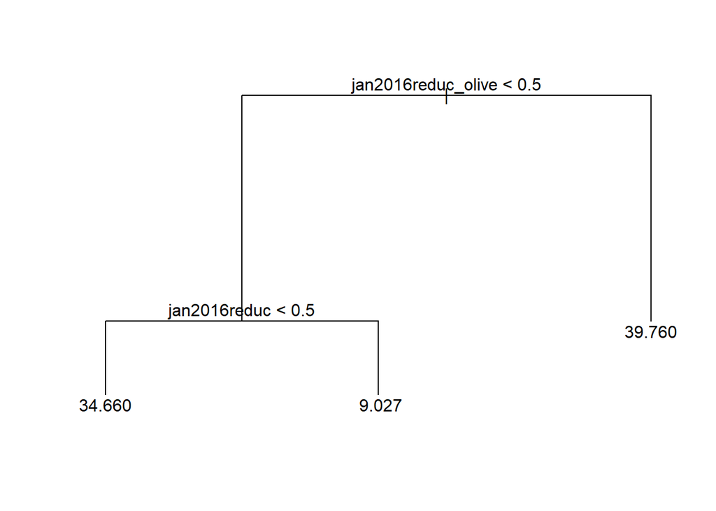

```r
oil_tree <- tree( price_nom ~ jan2016reduc + jan2016reduc_olive + jan2017reduc + jan2017reduc_olive , oil)
plot(oil_tree)
text(oil_tree)
```

```r
cheese_tree <- tree(price_nom ~ jan2016reduc + jan2016reduc_yellow + jan2017reduc + jan2017reduc_yellow, cheese)
#plot(cheese_tree)
#text(cheese_tree)
summary(cheese_tree)
```

```
##
## Regression tree:
## tree(formula = price_nom ~ jan2016reduc + jan2016reduc_yellow +
##     jan2017reduc + jan2017reduc_yellow, data = cheese)
## Variables actually used in tree construction:
## character(0)
## Number of terminal nodes:  1
## Residual mean deviance:  3232 = 3549000 / 1098
## Distribution of residuals:
##    Min. 1st Qu.  Median    Mean 3rd Qu.    Max.
## -45.540 -35.980  -7.936   0.000   7.912 594.400
```

*No good split was found in the cheese tarrif reduction model!*

# Linear Models

## Random Effects Models

### Random Effects full model (close to stata default panel data model)

```r
tuna_re_full <- plm(price_nom ~  jan2015reduc + jan2015reduc_tuna + jan2016reduc + jan2016reduc_tuna, data = tuna, effect="twoways", model = "random")
#stargazer(tuna_re_full)
nobs(tuna_re_full)
```

```
## [1] 1537
```

```r
coeftest(tuna_re_full, vcov.=function(x) vcovHC(x, type="sss",cluster="group"))
```

```
##
## t test of coefficients:
##
##                   Estimate Std. Error t value Pr(>|t|)
## (Intercept)        34.2399     2.7819 12.3079   <2e-16 ***
## jan2015reduc        7.2615     5.8945  1.2319   0.2182
## jan2015reduc_tuna  -7.9070     5.6567 -1.3978   0.1624
## jan2016reduc       -1.8872     2.3217 -0.8129   0.4164
## jan2016reduc_tuna   3.7580     2.4246  1.5500   0.1214
## ---
## Signif. codes:  0 '***' 0.001 '**' 0.01 '*' 0.05 '.' 0.1 ' ' 1
```

```r
oil_re_full <- plm(price_nom ~  jan2016reduc + jan2016reduc_olive + jan2017reduc + jan2017reduc_olive, data = oil, effect="twoways",model = "random")
nobs(oil_re_full)
```

```
## [1] 1204
```

```r
coeftest(oil_re_full, vcov.=function(x) vcovHC(x, type="sss",cluster="group"))
```

```
##
## t test of coefficients:
##
##                    Estimate Std. Error t value Pr(>|t|)
## (Intercept)        30.02388    1.94642 15.4252   <2e-16 ***
## jan2016reduc       -5.27314    3.87157 -1.3620   0.1734
## jan2016reduc_olive  5.05444    4.95445  1.0202   0.3078
## jan2017reduc        0.38209    0.87464  0.4369   0.6623
## jan2017reduc_olive  0.79688    1.16425  0.6845   0.4938
## ---
## Signif. codes:  0 '***' 0.001 '**' 0.01 '*' 0.05 '.' 0.1 ' ' 1
```

```r
cheese_re_full <- plm(price_nom ~  jan2016reduc + jan2016reduc_yellow + jan2017reduc + jan2017reduc_yellow, data = cheese, effect="twoways",model = "random")
nobs(cheese_re_full)
```

```
## [1] 1099
```

```r
coeftest(cheese_re_full, vcov.=function(x) vcovHC(x, type="sss",cluster="group"))
```

```
##
## t test of coefficients:
##
##                     Estimate Std. Error t value  Pr(>|t|)
## (Intercept)          50.6328     7.2927  6.9430 6.571e-12 ***
## jan2016reduc         -2.2758     7.8473 -0.2900    0.7719
## jan2016reduc_yellow  -3.0631     9.8368 -0.3114    0.7556
## jan2017reduc          1.2148     6.1434  0.1977    0.8433
## jan2017reduc_yellow  -2.2383    11.5652 -0.1935    0.8466
## ---
## Signif. codes:  0 '***' 0.001 '**' 0.01 '*' 0.05 '.' 0.1 ' ' 1
```

That’s the closest I got to the stata result of: xtreg price_nom jan2015reduc jan2015reduc_tuna jan2016reduc jan2016reduc_tuna, re it is actually closer to: xtreg price_nom jan2015reduc jan2015reduc_tuna jan2016reduc jan2016reduc_tuna, sa -> which is the the Random Effect small-sample Swamyâ“Arora estimator individual-level variance component.

### Random Effects - most significant time frames

The full Random effect model in the timeframes which give the most significant results (without cheese, which is insignificant):

```r
tuna_signif <- subset(tuna,date_n<382017)
tuna_re_full_significant <- plm(price_nom ~  jan2015reduc + jan2015reduc_tuna + jan2016reduc + jan2016reduc_tuna, data = tuna_signif, effect="twoways",model = "random")
coeftest(tuna_re_full_significant, vcov.=function(x) vcovHC(x, type="sss",cluster="group"))
```

```
##
## t test of coefficients:
##
##                   Estimate Std. Error t value Pr(>|t|)
## (Intercept)        34.1977     2.7840 12.2837   <2e-16 ***
## jan2015reduc        7.2979     5.8959  1.2378   0.2160
## jan2015reduc_tuna  -7.9325     5.6576 -1.4021   0.1611
## jan2016reduc       -1.8360     2.2721 -0.8081   0.4192
## jan2016reduc_tuna   3.6888     2.3774  1.5516   0.1210
## ---
## Signif. codes:  0 '***' 0.001 '**' 0.01 '*' 0.05 '.' 0.1 ' ' 1
```

```r
oil_signif <- subset(oil,year<2018)
oil_re_full_significant <- plm(price_nom ~  jan2016reduc + jan2016reduc_olive + jan2017reduc + jan2017reduc_olive, data = oil_signif, effect="twoways",model = "random")
coeftest(oil_re_full_significant, vcov.=function(x) vcovHC(x, type="sss",cluster="group"))
```

```
##
## t test of coefficients:
##
##                    Estimate Std. Error t value Pr(>|t|)
## (Intercept)        29.99671    1.94953 15.3867   <2e-16 ***
## jan2016reduc       -5.25907    3.87143 -1.3584   0.1746
## jan2016reduc_olive  5.02903    4.95484  1.0150   0.3103
## jan2017reduc        0.36738    0.79941  0.4596   0.6459
## jan2017reduc_olive  0.69327    1.12051  0.6187   0.5362
## ---
## Signif. codes:  0 '***' 0.001 '**' 0.01 '*' 0.05 '.' 0.1 ' ' 1
```

## Fixed effects models

### Fixed effect full model

Fixed effect is preffered since it has no prior assumption on the unobserved individual effect ci, and this effect may be correlated with the explantory variable (fixed effects assumption). Nothing is significant with the exception of tuna, but this significance might be a results of ommitting the jan2015reduc_tuna dummy, which is dropped because of singularities. Note that *in the fe model, the time-invariant regressors cancel!* - which means that the reduction dummy’s (jan2015reduc, etc…) will cancel out. *I believe they are failing due to the dummy variable trap!*

```r
# Tuna
tuna_without_sardin <- subset(tuna,!(sardin==1))
tuna_without_sardin$lsalary_industry_worker<-log(tuna_without_sardin$salary_industry_worker)
tuna_without_sardin_model <- plm(lprice_nom ~  jan2015reduc + jan2016reduc + proccess_fish_p2012 + lvalue_added_tax + lsalary_industry_worker , data = tuna_without_sardin, effect="individual",model = "random")
coeftest(tuna_without_sardin_model, vcov.=function(x) vcovHC(x,type="sss",cluster="group"))
```

```
##
## t test of coefficients:
##
##                           Estimate Std. Error t value Pr(>|t|)
## (Intercept)              2.1785066  2.5157177  0.8660  0.38668
## jan2015reduc             0.0423148  0.0239335  1.7680  0.07731 .
## jan2016reduc             0.0327320  0.0212604  1.5396  0.12392
## proccess_fish_p2012      0.0084574  0.0029641  2.8533  0.00440 **
## lvalue_added_tax        -3.5199634  6.0228391 -0.5844  0.55904
## lsalary_industry_worker  0.1080861  0.1624199  0.6655  0.50587
## ---
## Signif. codes:  0 '***' 0.001 '**' 0.01 '*' 0.05 '.' 0.1 ' ' 1
```

```r
stargazer(coeftest(tuna_without_sardin_model, vcov.=function(x) vcovHC(x,type="sss",cluster="group")),type="latex")
```

```
##
## % Table created by stargazer v.5.2.2 by Marek Hlavac, Harvard University. E-mail: hlavac at fas.harvard.edu
## % Date and time: Sun, Dec 22, 2019 - 14:48:49
## \begin{table}[!htbp] \centering
##   \caption{}
##   \label{}
## \begin{tabular}{@{\extracolsep{5pt}}lc}
## \\[-1.8ex]\hline
## \hline \\[-1.8ex]
##  & \multicolumn{1}{c}{\textit{Dependent variable:}} \\
## \cline{2-2}
## \\[-1.8ex] &   \\
## \hline \\[-1.8ex]
##  jan2015reduc & 0.042$^{*}$ \\
##   & (0.024) \\
##   & \\
##  jan2016reduc & 0.033 \\
##   & (0.021) \\
##   & \\
##  proccess\_fish\_p2012 & 0.008$^{***}$ \\
##   & (0.003) \\
##   & \\
##  lvalue\_added\_tax & $-$3.520 \\
##   & (6.023) \\
##   & \\
##  lsalary\_industry\_worker & 0.108 \\
##   & (0.162) \\
##   & \\
##  Constant & 2.179 \\
##   & (2.516) \\
##   & \\
## \hline \\[-1.8ex]
## \hline
## \hline \\[-1.8ex]
## \textit{Note:}  & \multicolumn{1}{r}{$^{*}$p$<$0.1; $^{**}$p$<$0.05; $^{***}$p$<$0.01} \\
## \end{tabular}
## \end{table}
```

```r
'
#summary(tuna_without_sardin_model)
# Oil
tuna_without_sardin <- subset(tuna,!(sardin==1))
tuna_without_sardin$lsalary_industry_worker<-log(tuna_without_sardin$salary_industry_worker)
tuna_without_sardin_model <- plm(lprice_nom ~  jan2015reduc + jan2016reduc + proccess_fish_p2012 + lvalue_added_tax + lsalary_industry_worker , data = tuna_without_sardin, effect="individual",model = "within")
coeftest(tuna_without_sardin_model, vcov.=function(x) vcovHC(x,type="sss",cluster="group"));within_intercept(tuna_fe_full,vcov.=function(x) vcovHC(x, type="sss",cluster="group"))
summary(tuna_without_sardin_model)
# cheese
tuna_without_sardin <- subset(tuna,!(sardin==1))
tuna_without_sardin$lsalary_industry_worker<-log(tuna_without_sardin$salary_industry_worker)
tuna_without_sardin_model <- plm(lprice_nom ~  jan2015reduc + jan2016reduc + proccess_fish_p2012 + lvalue_added_tax + lsalary_industry_worker , data = tuna_without_sardin, effect="individual",model = "within")
coeftest(tuna_without_sardin_model, vcov.=function(x) vcovHC(x,type="sss",cluster="group"));within_intercept(tuna_fe_full,vcov.=function(x) vcovHC(x, type="sss",cluster="group"))
summary(tuna_without_sardin_model)


oil_fe_full <- plm(price_nom ~  jan2016reduc + jan2016reduc_olive + jan2017reduc + jan2017reduc_olive, data = oil, effect="twoways",model = "within")
coeftest(oil_fe_full, vcov.=function(x) vcovHC(x, type="sss",cluster="group"));within_intercept(oil_fe_full,vcov.=function(x) vcovHC(x, type="sss",cluster="group"))
cheese_fe_full <- plm(price_nom ~  jan2016reduc + jan2016reduc_yellow + jan2017reduc + jan2017reduc_yellow, data = cheese, effect="twoways",model = "within")
coeftest(cheese_fe_full, vcov.=function(x) vcovHC(x, type="sss",cluster="group"));within_intercept(cheese_fe_full,vcov.=function(x) vcovHC(x, type="sss",cluster="group"))
'
```

[output not shown]

```r
tuna_fe_full <- plm(price_nom ~  jan2015reduc + jan2015reduc_tuna + jan2016reduc + jan2016reduc_tuna, data = tuna, effect="twoways",model = "within")
coeftest(tuna_fe_full, vcov.=function(x) vcovHC(x,type="sss",cluster="group"));within_intercept(tuna_fe_full,vcov.=function(x) vcovHC(x, type="sss",cluster="group"))
```

```
##
## t test of coefficients:
##
##                   Estimate Std. Error t value Pr(>|t|)
## jan2016reduc_tuna   4.1497     2.4491  1.6943  0.09042 .
## ---
## Signif. codes:  0 '***' 0.001 '**' 0.01 '*' 0.05 '.' 0.1 ' ' 1
```

```
## (overall_intercept)
##            35.39186
## attr(,"se")
## [1] 0.6203893
```

```r
summary(tuna_fe_full)
```

```
## Twoways effects Within Model
##
## Call:
## plm(formula = price_nom ~ jan2015reduc + jan2015reduc_tuna +
##     jan2016reduc + jan2016reduc_tuna, data = tuna, effect = "twoways",
##     model = "within")
##
## Unbalanced Panel: n = 58, T = 2-38, N = 1537
##
## Residuals:
##       Min.    1st Qu.     Median    3rd Qu.       Max.
## -24.775911  -2.119838   0.062399   2.231727  52.619735
##
## Coefficients:
##                   Estimate Std. Error t-value  Pr(>|t|)
## jan2016reduc_tuna   4.1497     1.1055  3.7536 0.0001813 ***
## ---
## Signif. codes:  0 '***' 0.001 '**' 0.01 '*' 0.05 '.' 0.1 ' ' 1
##
## Total Sum of Squares:    46311
## Residual Sum of Squares: 45863
## R-Squared:      0.0096828
## Adj. R-Squared: -0.055605
## F-statistic: 14.0893 on 1 and 1441 DF, p-value: 0.00018126
```

```r
oil_fe_full <- plm(price_nom ~  jan2016reduc + jan2016reduc_olive + jan2017reduc + jan2017reduc_olive, data = oil, effect="twoways",model = "within")
coeftest(oil_fe_full, vcov.=function(x) vcovHC(x, type="sss",cluster="group"));within_intercept(oil_fe_full,vcov.=function(x) vcovHC(x, type="sss",cluster="group"))
```

```
##
## t test of coefficients:
##
##                    Estimate Std. Error t value Pr(>|t|)
## jan2016reduc_olive -0.68485    1.09297 -0.6266   0.5311
## jan2017reduc_olive  0.77394    0.91614  0.8448   0.3984
```

```
## (overall_intercept)
##            29.33286
## attr(,"se")
## [1] 0.6807668
```

```r
cheese_fe_full <- plm(price_nom ~  jan2016reduc + jan2016reduc_yellow + jan2017reduc + jan2017reduc_yellow, data = cheese, effect="twoways",model = "within")
coeftest(cheese_fe_full, vcov.=function(x) vcovHC(x, type="sss",cluster="group"));within_intercept(cheese_fe_full,vcov.=function(x) vcovHC(x, type="sss",cluster="group"))
```

```
##
## t test of coefficients:
##
##                     Estimate Std. Error t value Pr(>|t|)
## jan2016reduc_yellow   6.9405    10.3328  0.6717   0.5019
## jan2017reduc_yellow  -1.8925     9.8176 -0.1928   0.8472
```

```
## (overall_intercept)
##            41.88344
## attr(,"se")
## [1] 9.173686
```

Let’s check for linear dependency in the tuna fe model:

```r
alias(tuna_fe_full)
```

```
## Model :
## [1] "price_nom ~ jan2015reduc + jan2015reduc_tuna + jan2016reduc + "
## [2] "    jan2016reduc_tuna"
```

```r
tuna_fe_full_not_linear <- plm(price_nom ~  jan2015reduc_tuna + jan2016reduc + jan2016reduc_tuna, data = tuna, effect="twoways",model = "within")
coeftest(tuna_fe_full_not_linear, vcov.=function(x) vcovHC(x, type="sss",cluster="group"));within_intercept(tuna_fe_full_not_linear,vcov.=function(x) vcovHC(x, type="sss",cluster="group"))
```

```
##
## t test of coefficients:
##
##                   Estimate Std. Error t value Pr(>|t|)
## jan2016reduc_tuna   4.1497     2.4491  1.6943  0.09042 .
## ---
## Signif. codes:  0 '***' 0.001 '**' 0.01 '*' 0.05 '.' 0.1 ' ' 1
```

```
## (overall_intercept)
##            35.39186
## attr(,"se")
## [1] 0.6203893
```

```r
summary(tuna_fe_full_not_linear)
```

```
## Twoways effects Within Model
##
## Call:
## plm(formula = price_nom ~ jan2015reduc_tuna + jan2016reduc +
##     jan2016reduc_tuna, data = tuna, effect = "twoways", model = "within")
##
## Unbalanced Panel: n = 58, T = 2-38, N = 1537
##
## Residuals:
##       Min.    1st Qu.     Median    3rd Qu.       Max.
## -24.775911  -2.119838   0.062399   2.231727  52.619735
##
## Coefficients:
##                   Estimate Std. Error t-value  Pr(>|t|)
## jan2016reduc_tuna   4.1497     1.1055  3.7536 0.0001813 ***
## ---
## Signif. codes:  0 '***' 0.001 '**' 0.01 '*' 0.05 '.' 0.1 ' ' 1
##
## Total Sum of Squares:    46311
## Residual Sum of Squares: 45863
## R-Squared:      0.0096828
## Adj. R-Squared: -0.055605
## F-statistic: 14.0893 on 1 and 1441 DF, p-value: 0.00018126
```

### Fixed effect full model - most significant time frames

```r
tuna_fe_full_significant <- plm(price_nom ~  jan2015reduc_tuna + jan2016reduc + jan2016reduc_tuna, data = tuna_signif, effect="twoways",model = "within")
coeftest(tuna_fe_full_significant, vcov.=function(x) vcovHC(x, type="sss",cluster="group"));within_intercept(tuna_fe_full_significant,vcov.=function(x) vcovHC(x, type="sss",cluster="group"))
```

```
##
## t test of coefficients:
##
##                   Estimate Std. Error t value Pr(>|t|)
## jan2016reduc_tuna   4.0773     2.4064  1.6944  0.09042 .
## ---
## Signif. codes:  0 '***' 0.001 '**' 0.01 '*' 0.05 '.' 0.1 ' ' 1
```

```
## (overall_intercept)
##            35.44285
## attr(,"se")
## [1] 0.6217915
```

```r
oil_fe_full_significant <- plm(price_nom ~  jan2016reduc + jan2016reduc_olive + jan2017reduc + jan2017reduc_olive, data = oil_signif, effect="twoways",model = "within")
coeftest(oil_fe_full_significant, vcov.=function(x) vcovHC(x, type="sss",cluster="group"));within_intercept(oil_fe_full_significant,vcov.=function(x) vcovHC(x, type="sss",cluster="group"))
```

```
##
## t test of coefficients:
##
##                    Estimate Std. Error t value Pr(>|t|)
## jan2016reduc_olive -0.68579    1.09373 -0.6270   0.5308
## jan2017reduc_olive  0.66989    0.93539  0.7162   0.4740
```

```
## (overall_intercept)
##             29.3384
## attr(,"se")
## [1] 0.6779255
```

## Hausman Test: Random Effects Vs. Fixed effects

We’ll use the Hausman Test for Panel Models in order to determine which model suits best the data - fixed effect or random effect:

```r
phtest(tuna_fe_full,tuna_re_full)
```

```
##
##  Hausman Test
##
## data:  price_nom ~ jan2015reduc + jan2015reduc_tuna + jan2016reduc +  ...
## chisq = 0.12901, df = 1, p-value = 0.7195
## alternative hypothesis: one model is inconsistent
```

```r
phtest(oil_fe_full,oil_re_full)
```

```
##
##  Hausman Test
##
## data:  price_nom ~ jan2016reduc + jan2016reduc_olive + jan2017reduc +  ...
## chisq = 25.678, df = 2, p-value = 2.656e-06
## alternative hypothesis: one model is inconsistent
```

```r
phtest(cheese_fe_full,cheese_re_full)
```

```
##
##  Hausman Test
##
## data:  price_nom ~ jan2016reduc + jan2016reduc_yellow + jan2017reduc +  ...
## chisq = 0.47704, df = 2, p-value = 0.7878
## alternative hypothesis: one model is inconsistent
```

```r
phtest(tuna_fe_full_significant,tuna_re_full_significant)
```

```
##
##  Hausman Test
##
## data:  price_nom ~ jan2015reduc_tuna + jan2016reduc + jan2016reduc_tuna
## chisq = 0.12441, df = 1, p-value = 0.7243
## alternative hypothesis: one model is inconsistent
```

```r
phtest(oil_fe_full_significant,oil_re_full_significant)
```

```
##
##  Hausman Test
##
## data:  price_nom ~ jan2016reduc + jan2016reduc_olive + jan2017reduc +  ...
## chisq = 25.532, df = 2, p-value = 2.857e-06
## alternative hypothesis: one model is inconsistent
```

*The tuna and cheese models corresponds to random effect, while the oil corresponds to fixed effects.*

# Log-Linear Models

## Random Effects

### Random Effects full model (close to stata default panel data model)

```r
tuna_lre_full <- plm(lprice_nom ~  jan2015reduc + jan2015reduc_tuna + jan2016reduc + jan2016reduc_tuna, data = tuna, effect="twoways",model = "random")
coeftest(tuna_lre_full, vcov.=function(x) vcovHC(x, type="sss",cluster="group"))
```

```
##
## t test of coefficients:
##
##                    Estimate Std. Error t value Pr(>|t|)
## (Intercept)        3.434965   0.096295 35.6712   <2e-16 ***
## jan2015reduc       0.151955   0.240924  0.6307   0.5283
## jan2015reduc_tuna -0.142726   0.231523 -0.6165   0.5377
## jan2016reduc      -0.161375   0.172141 -0.9375   0.3487
## jan2016reduc_tuna  0.246953   0.180095  1.3712   0.1705
## ---
## Signif. codes:  0 '***' 0.001 '**' 0.01 '*' 0.05 '.' 0.1 ' ' 1
```

```r
oil_lre_full <- plm(lprice_nom ~  jan2016reduc + jan2016reduc_olive + jan2017reduc + jan2017reduc_olive, data = oil, effect="twoways",model = "random")
coeftest(oil_lre_full, vcov.=function(x) vcovHC(x, type="sss",cluster="group"))
```

```
##
## t test of coefficients:
##
##                     Estimate Std. Error t value Pr(>|t|)
## (Intercept)         3.180841   0.091360 34.8166  < 2e-16 ***
## jan2016reduc       -0.318968   0.192570 -1.6564  0.09791 .
## jan2016reduc_olive  0.339372   0.234363  1.4481  0.14786
## jan2017reduc        0.055844   0.046395  1.2037  0.22896
## jan2017reduc_olive -0.035841   0.052414 -0.6838  0.49424
## ---
## Signif. codes:  0 '***' 0.001 '**' 0.01 '*' 0.05 '.' 0.1 ' ' 1
```

```r
cheese_lre_full <- plm(lprice_nom ~  jan2016reduc + jan2016reduc_yellow + jan2017reduc + jan2017reduc_yellow, data = cheese, effect="twoways",model = "random")
coeftest(cheese_lre_full, vcov.=function(x) vcovHC(x, type="sss",cluster="group"))
```

```
##
## t test of coefficients:
##
##                      Estimate Std. Error t value Pr(>|t|)
## (Intercept)          3.868823   0.077953 49.6301   <2e-16 ***
## jan2016reduc        -0.038302   0.096824 -0.3956   0.6925
## jan2016reduc_yellow -0.565229   0.375026 -1.5072   0.1321
## jan2017reduc         0.018693   0.072396  0.2582   0.7963
## jan2017reduc_yellow -0.146992   0.207678 -0.7078   0.4793
## ---
## Signif. codes:  0 '***' 0.001 '**' 0.01 '*' 0.05 '.' 0.1 ' ' 1
```

### Random Effects - most significant time frames

```r
tuna_signif <- subset(tuna,date_n<382017)
tuna_lre_full_significant <- plm(lprice_nom ~  jan2015reduc + jan2015reduc_tuna + jan2016reduc + jan2016reduc_tuna, data = tuna_signif, effect="twoways",model = "random")
coeftest(tuna_lre_full_significant, vcov.=function(x) vcovHC(x, type="sss",cluster="group"))
```

```
##
## t test of coefficients:
##
##                    Estimate Std. Error t value Pr(>|t|)
## (Intercept)        3.433754   0.096329 35.6461   <2e-16 ***
## jan2015reduc       0.154448   0.240950  0.6410   0.5216
## jan2015reduc_tuna -0.144907   0.231543 -0.6258   0.5315
## jan2016reduc      -0.167325   0.173612 -0.9638   0.3353
## jan2016reduc_tuna  0.252684   0.181526  1.3920   0.1641
## ---
## Signif. codes:  0 '***' 0.001 '**' 0.01 '*' 0.05 '.' 0.1 ' ' 1
```

```r
oil_signif <- subset(oil,year<2018)
oil_lre_full_significant <- plm(lprice_nom ~  jan2016reduc + jan2016reduc_olive + jan2017reduc + jan2017reduc_olive, data = oil_signif, effect="twoways",model = "random")
coeftest(oil_lre_full_significant, vcov.=function(x) vcovHC(x, type="sss",cluster="group"))
```

```
##
## t test of coefficients:
##
##                     Estimate Std. Error t value Pr(>|t|)
## (Intercept)         3.178378   0.091683 34.6670   <2e-16 ***
## jan2016reduc       -0.311745   0.193810 -1.6085   0.1080
## jan2016reduc_olive  0.331198   0.235633  1.4056   0.1601
## jan2017reduc        0.053560   0.042177  1.2699   0.2044
## jan2017reduc_olive -0.037524   0.048795 -0.7690   0.4420
## ---
## Signif. codes:  0 '***' 0.001 '**' 0.01 '*' 0.05 '.' 0.1 ' ' 1
```

```r
cheese_signif <- subset(cheese,date_n<382017)
cheese_lre_full_significant <- plm(lprice_nom ~  jan2016reduc + jan2016reduc_yellow + jan2017reduc + jan2017reduc_yellow, data = cheese_signif, effect="twoways",model = "random")
coeftest(cheese_lre_full, vcov.=function(x) vcovHC(x, type="sss",cluster="group"));within_intercept(tuna_fe_full,vcov.=function(x) vcovHC(x, type="sss",cluster="group"))
```

```
##
## t test of coefficients:
##
##                      Estimate Std. Error t value Pr(>|t|)
## (Intercept)          3.868823   0.077953 49.6301   <2e-16 ***
## jan2016reduc        -0.038302   0.096824 -0.3956   0.6925
## jan2016reduc_yellow -0.565229   0.375026 -1.5072   0.1321
## jan2017reduc         0.018693   0.072396  0.2582   0.7963
## jan2017reduc_yellow -0.146992   0.207678 -0.7078   0.4793
## ---
## Signif. codes:  0 '***' 0.001 '**' 0.01 '*' 0.05 '.' 0.1 ' ' 1
```

```
## (overall_intercept)
##            35.39186
## attr(,"se")
## [1] 0.6203893
```

## Fixed Effects models

### Fixed effect full model

```r
tuna_lfe_full <- plm(lprice_nom ~  jan2015reduc_tuna + jan2016reduc + jan2016reduc_tuna, data = tuna, effect="twoways",model = "within")
coeftest(tuna_lfe_full, vcov.=function(x) vcovHC(x, type="sss",cluster="group"));within_intercept(tuna_fe_full,vcov.=function(x) vcovHC(x, type="sss",cluster="group"))
```

```
##
## t test of coefficients:
##
##                   Estimate Std. Error t value Pr(>|t|)
## jan2016reduc_tuna  0.22650    0.18919  1.1972   0.2314
```

```
## (overall_intercept)
##            35.39186
## attr(,"se")
## [1] 0.6203893
```

```r
oil_lfe_full <- plm(lprice_nom ~  jan2016reduc + jan2016reduc_olive + jan2017reduc + jan2017reduc_olive, data = oil, effect="twoways",model = "within")
coeftest(oil_lfe_full, vcov.=function(x) vcovHC(x, type="sss",cluster="group"));within_intercept(tuna_fe_full,vcov.=function(x) vcovHC(x, type="sss",cluster="group"))
```

```
##
## t test of coefficients:
##
##                     Estimate Std. Error t value Pr(>|t|)
## jan2016reduc_olive -0.019719   0.044392 -0.4442   0.6570
## jan2017reduc_olive -0.037052   0.029585 -1.2524   0.2107
```

```
## (overall_intercept)
##            35.39186
## attr(,"se")
## [1] 0.6203893
```

```r
cheese_lfe_full <- plm(lprice_nom ~  jan2016reduc + jan2016reduc_yellow + jan2017reduc + jan2017reduc_yellow, data = cheese, effect="twoways",model = "within")
coeftest(cheese_lfe_full, vcov.=function(x) vcovHC(x, type="sss",cluster="group"));within_intercept(tuna_fe_full,vcov.=function(x) vcovHC(x, type="sss",cluster="group"))
```

```
##
## t test of coefficients:
##
##                     Estimate Std. Error t value Pr(>|t|)
## jan2016reduc_yellow -0.65328    0.33600 -1.9443   0.0522 .
## jan2017reduc_yellow -0.14395    0.18492 -0.7784   0.4365
## ---
## Signif. codes:  0 '***' 0.001 '**' 0.01 '*' 0.05 '.' 0.1 ' ' 1
```

```
## (overall_intercept)
##            35.39186
## attr(,"se")
## [1] 0.6203893
```

**In comparison to the linear fixed-effects model, the log-linear fixed-effects models of cheese returned significant results: the jan2016reduc_yellow negative effect was significant to the level of 6%.**

### Fixed effect full model - most significant time frames

```r
tuna_lfe_full_significant <- plm(lprice_nom ~  jan2015reduc_tuna + jan2016reduc + jan2016reduc_tuna, data = tuna_signif, effect="twoways",model = "within")
coeftest(tuna_lfe_full_significant, vcov.=function(x) vcovHC(x, type="sss",cluster="group"));within_intercept(tuna_fe_full,vcov.=function(x) vcovHC(x, type="sss",cluster="group"))
```

```
##
## t test of coefficients:
##
##                   Estimate Std. Error t value Pr(>|t|)
## jan2016reduc_tuna  0.23184    0.19000  1.2202   0.2226
```

```
## (overall_intercept)
##            35.39186
## attr(,"se")
## [1] 0.6203893
```

```r
oil_lfe_full_significant <- plm(lprice_nom ~  jan2016reduc + jan2016reduc_olive + jan2017reduc + jan2017reduc_olive, data = oil_signif, effect="twoways",model = "within")
coeftest(oil_lfe_full_significant, vcov.=function(x) vcovHC(x, type="sss",cluster="group"));within_intercept(tuna_fe_full,vcov.=function(x) vcovHC(x, type="sss",cluster="group"))
```

```
##
## t test of coefficients:
##
##                     Estimate Std. Error t value Pr(>|t|)
## jan2016reduc_olive -0.019788   0.044377 -0.4459   0.6558
## jan2017reduc_olive -0.038781   0.027674 -1.4014   0.1614
```

```
## (overall_intercept)
##            35.39186
## attr(,"se")
## [1] 0.6203893
```

```r
cheese_lfe_full <- plm(lprice_nom ~  jan2016reduc + jan2016reduc_yellow + jan2017reduc + jan2017reduc_yellow, data = cheese_signif, effect="twoways",model = "within")
coeftest(cheese_lfe_full, vcov.=function(x) vcovHC(x, type="sss",cluster="group"));within_intercept(tuna_fe_full,vcov.=function(x) vcovHC(x, type="sss",cluster="group"))
```

```
##
## t test of coefficients:
##
##                     Estimate Std. Error t value Pr(>|t|)
## jan2016reduc_yellow -0.65314    0.33592 -1.9443  0.05221 .
## jan2017reduc_yellow -0.13229    0.18324 -0.7220  0.47053
## ---
## Signif. codes:  0 '***' 0.001 '**' 0.01 '*' 0.05 '.' 0.1 ' ' 1
```

```
## (overall_intercept)
##            35.39186
## attr(,"se")
## [1] 0.6203893
```

## Hausman Test: Random Effects Vs. Fixed effects

```r
phtest(tuna_lfe_full,tuna_lre_full)
```

```
##
##  Hausman Test
##
## data:  lprice_nom ~ jan2015reduc_tuna + jan2016reduc + jan2016reduc_tuna
## chisq = 0.015186, df = 1, p-value = 0.9019
## alternative hypothesis: one model is inconsistent
```

```r
phtest(oil_lfe_full,oil_lre_full)
```

```
##
##  Hausman Test
##
## data:  lprice_nom ~ jan2016reduc + jan2016reduc_olive + jan2017reduc +  ...
## chisq = 1.6724, df = 2, p-value = 0.4334
## alternative hypothesis: one model is inconsistent
```

```r
phtest(cheese_lfe_full,cheese_lre_full)
```

```
##
##  Hausman Test
##
## data:  lprice_nom ~ jan2016reduc + jan2016reduc_yellow + jan2017reduc +  ...
## chisq = 0.70679, df = 2, p-value = 0.7023
## alternative hypothesis: one model is inconsistent
```

```r
phtest(tuna_lfe_full_significant,tuna_lre_full_significant)
```

```
##
##  Hausman Test
##
## data:  lprice_nom ~ jan2015reduc_tuna + jan2016reduc + jan2016reduc_tuna
## chisq = 0.015705, df = 1, p-value = 0.9003
## alternative hypothesis: one model is inconsistent
```

```r
phtest(oil_lfe_full_significant,oil_lre_full_significant)
```

```
##
##  Hausman Test
##
## data:  lprice_nom ~ jan2016reduc + jan2016reduc_olive + jan2017reduc +  ...
## chisq = 1.5826, df = 2, p-value = 0.4532
## alternative hypothesis: one model is inconsistent
```

The p-value much is bigger than 0.05 on all tests ->> *All of the models are significantly more suited for the random effects settings.* *So from now on we’ll continue only with the random effects.*

## Random Effects models with lags

### full log model with lead and lags

```r
#tuna
tuna_lre_full_lags <- plm(lprice_nom ~  jan2015reduc + lead(jan2015reduc_tuna,1) + jan2015reduc_tuna + lag(jan2015reduc_tuna,1) + jan2016reduc + lead(jan2016reduc_tuna,1) + jan2016reduc_tuna + lag(jan2016reduc_tuna,1) , data = tuna, effect="twoways",model = "random")
coeftest(tuna_lre_full_lags, vcov.=function(x) vcovHC(x, type="sss",cluster="group"))
```

```
##
## t test of coefficients:
##
##                             Estimate Std. Error t value Pr(>|t|)
## (Intercept)                 3.423881   0.105044 32.5946  < 2e-16 ***
## jan2015reduc                0.163402   0.244813  0.6675  0.50458
## lead(jan2015reduc_tuna, 1) -0.052053   0.055274 -0.9417  0.34648
## jan2015reduc_tuna          -0.077773   0.231480 -0.3360  0.73693
## lag(jan2015reduc_tuna, 1)  -0.019544   0.040311 -0.4848  0.62787
## jan2016reduc               -0.161376   0.172789 -0.9339  0.35048
## lead(jan2016reduc_tuna, 1)  0.040518   0.056515  0.7169  0.47352
## jan2016reduc_tuna           0.136239   0.180542  0.7546  0.45060
## lag(jan2016reduc_tuna, 1)   0.078730   0.036216  2.1739  0.02987 *
## ---
## Signif. codes:  0 '***' 0.001 '**' 0.01 '*' 0.05 '.' 0.1 ' ' 1
```

```r
#oil
oil_lre_full_lags <- plm(lprice_nom ~  jan2016reduc + lead(jan2016reduc_olive,1) + jan2016reduc_olive + lag(jan2016reduc_olive,1) + jan2017reduc + lead(jan2017reduc_olive,1) + jan2017reduc_olive + lag(jan2017reduc_olive,1) , data = oil, effect="twoways",model = "random")
coeftest(oil_lre_full_lags, vcov.=function(x) vcovHC(x, type="sss",cluster="group"))
```

```
##
## t test of coefficients:
##
##                              Estimate Std. Error t value  Pr(>|t|)
## (Intercept)                  3.170880   0.098999 32.0293 < 2.2e-16 ***
## jan2016reduc                -0.463649   0.147185 -3.1501  0.001673 **
## lead(jan2016reduc_olive, 1)  0.344786   0.077750  4.4345 1.008e-05 ***
## jan2016reduc_olive           0.232754   0.178018  1.3075  0.191304
## lag(jan2016reduc_olive, 1)   0.024349   0.025426  0.9576  0.338437
## jan2017reduc                 0.057148   0.040412  1.4141  0.157583
## lead(jan2017reduc_olive, 1) -0.224273   0.047582 -4.7134 2.722e-06 ***
## jan2017reduc_olive           0.136101   0.060137  2.2632  0.023804 *
## lag(jan2017reduc_olive, 1)   0.042456   0.025904  1.6390  0.101476
## ---
## Signif. codes:  0 '***' 0.001 '**' 0.01 '*' 0.05 '.' 0.1 ' ' 1
```

```r
# Cheese
cheese_lre_full_lags <- plm(lprice_nom ~  jan2016reduc + lead(jan2016reduc_yellow,1) + jan2016reduc_yellow + lag(jan2016reduc_yellow,1) + jan2017reduc + lead(jan2017reduc_yellow,1) + jan2017reduc_yellow + lag(jan2017reduc_yellow,1) , data = cheese, effect="twoways",model = "random")
coeftest(cheese_lre_full_lags, vcov.=function(x) vcovHC(x, type="sss",cluster="group"))
```

```
##
## t test of coefficients:
##
##                               Estimate Std. Error t value Pr(>|t|)
## (Intercept)                   3.905962   0.089138 43.8194  < 2e-16 ***
## jan2016reduc                 -0.048349   0.105785 -0.4571  0.64775
## lead(jan2016reduc_yellow, 1)  0.082195   0.098338  0.8358  0.40347
## jan2016reduc_yellow          -0.269364   0.253139 -1.0641  0.28757
## lag(jan2016reduc_yellow, 1)  -0.448539   0.216443 -2.0723  0.03852 *
## jan2017reduc                  0.018513   0.071776  0.2579  0.79652
## lead(jan2017reduc_yellow, 1) -0.066813   0.168782 -0.3959  0.69231
## jan2017reduc_yellow          -0.226080   0.192692 -1.1733  0.24100
## lag(jan2017reduc_yellow, 1)   0.194266   0.137323  1.4147  0.15752
## ---
## Signif. codes:  0 '***' 0.001 '**' 0.01 '*' 0.05 '.' 0.1 ' ' 1
```